# IgIDivA

Laura Zaragoza-Infante

20/5/2022

# Introduction

`IgIDivA` (Immunoglobulin Intraclonal Diversification Analysis) is a purpose-built tool for the analysis of the intraclonal diversification process using high-throughput sequencing data.  
It is written in [shiny](https://shiny.rstudio.com/). Every step of the analysis can be performed interactively, thus not requiring any programming skills.  
It takes as input the output files “clonotypes_computation” and “grouped_alignment_nt” from the [`tripr`](https://bio.tools/TRIP_-_T-cell_Receptor_Immunoglobulin_Profiler) package.  
Functions for an `R` command-line use are also available.

## Installation

The `IgIDivA` scripts can be freely downloaded [here](https://github.com/laurazara/IgIDivA). It requires `R` (version “4.1”), which can be installed on any operating system [e.g., Linux, Windows, MacOS] from [CRAN](https://cran.r-project.org/). Installation with Docker will be available in the coming future.

All the packages that need to be installed in your `R` session are the following:

```r
install.packages("shiny")
install.packages("shinyFiles")
install.packages("fs")
install.packages("pdftools")
install.packages("purrr")
install.packages("DT")
install.packages("bslib")
install.packages("shinyhelper")
install.packages("data.table")
install.packages("stringr")
install.packages("RGenetics")
install.packages("dplyr")
install.packages("ggsci")
install.packages("tidygraph")
install.packages("ggraph")
install.packages("igraph")
install.packages("ggplot2")
install.packages("ggpubr")
install.packages("rstatix")
```

All the scripts from `IgIDivA` need to be downloaded in the same folder. All the input files should also be stored in a folder.

# Running `IgIDivA` as a `shiny` application

In order to start the `shiny` app, please open the script `app.R` in your `R` session and press the button `Run App`.

[figure not shown]

## Import data

In this tab users can import their data by selecting the directory where the data is stored, by pressing the **Choose input directory** button.

[figure not shown]

The tool takes as input for each sample the [`tripr`](https://bio.tools/TRIP_-_T-cell_Receptor_Immunoglobulin_Profiler) output files “highly similar clonotype computation” and “grouped alignment nt”, in text format (.txt).  
The input folder is selected:

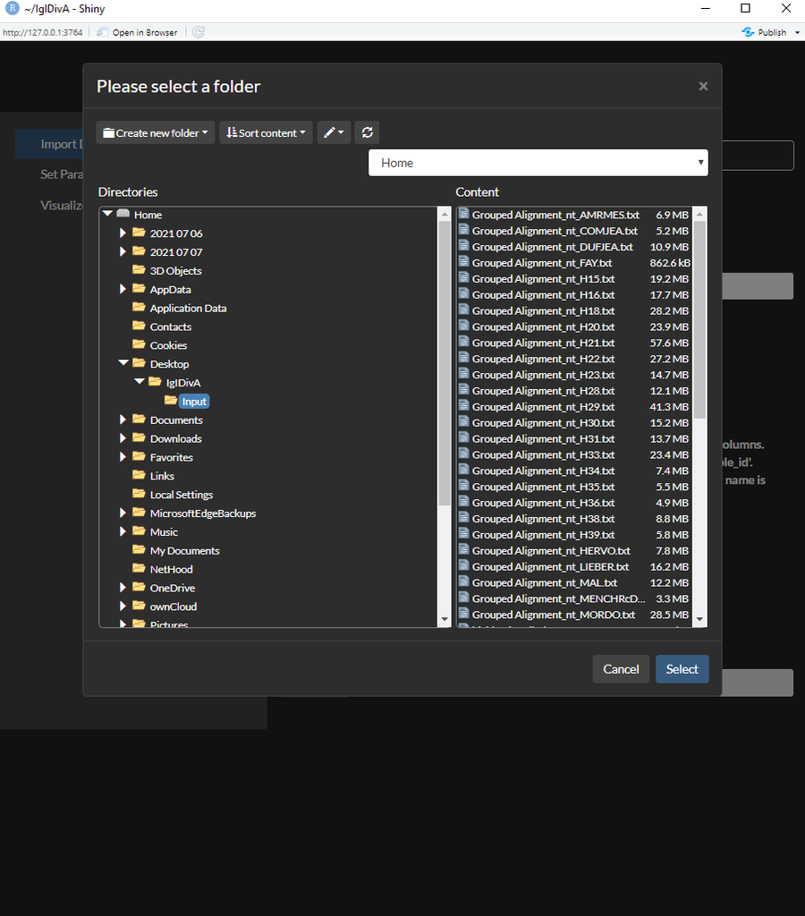

Once the Input folder has been selected, users should verify it by pressing the button **Upload**. Then users can choose which samples from the Input folder they want to include in the analysis.

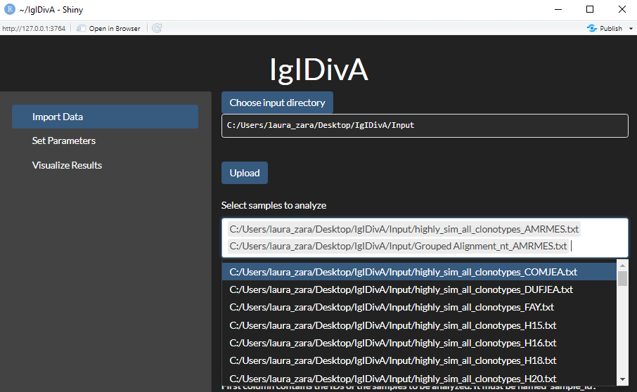

Users should subsequently verify it by pressing the button **Verify**.

### Including groups to compare (optional)

In order to make comparisons between groups of samples, the user needs to create a `tab-delimited` file with two columns.  
The first column should be named “sample_id” and should include the names of the samples.  
The second column should include the name of the group that each sample belongs to. By default the name of the column is “group_name”, but it can be modified in the **Enter the name chosen for the second column** button.

```r
groups = data.table::fread("SampleGroups.txt", header = TRUE,
                               sep = "\t",
                               stringsAsFactors = FALSE)
head(groups)
```

```
#>    sample_id      group_name
#> 1:    AMRMES CLL subset #169
#> 2:    COMJEA   CLL subset #2
#> 3:    DUFJEA   CLL subset #2
#> 4:       FAY   CLL subset #2
#> 5:       H15   CLL subset #2
#> 6:       H16   CLL subset #2
```

Once created, the file can be uploaded through the **Browse** button. When it is uploaded, a message “Upload completed” will appear.

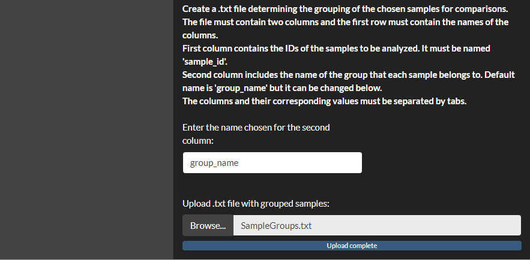

## Set Parameters

There are different parameters that can be applied:

- **Enter starting column**:  
  From the Grouped Alignment file, choose which column corresponds to the beginning of the sequence. If the experimental procedure amplifies the whole immunoglobulin with, for example, leader primers, the starting column should be 5 [the initial 4 columns of the file contain additional information]. If the experimental procedure uses primers that bind in a more downstream position, the starting column should be changed [for example, for primers binding to the FR1 region of the immunoglobulin, the starting column position could be 59].
- **Enter ending column**:  
  From the Grouped Alignment file, choose which column corresponds to the end of the sequence [the end of the FR3 region]. The default is position 313.
- **Enter threshold minimum reads for the nodes**:  
  Choose the minimum number of reads that need to be part of a nucleotide variant (node) for it to be considered in the analysis.
- **Enter p-value threshold**:  
  For the metrics comparison between groups of samples, choose the p-value threshold for a comparison to be considered as statistically significant.
- **Do you want the p-values to be adjusted?**:  
  Choose between p-value or adjusted p-value.

[figure not shown]

- **Clonotypes to be taken into account for the analysis**:  
  Choose the clonotypes to be included in the analysis. One approach would be, for example, to include the first [the most frequent] clonotype. If more than one clonotype is selected, their indeces have to be separated by comma.

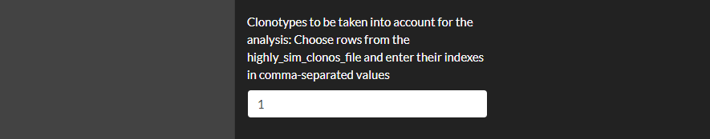

### Parameters: processing

There are different options for the analysis that can be selected:

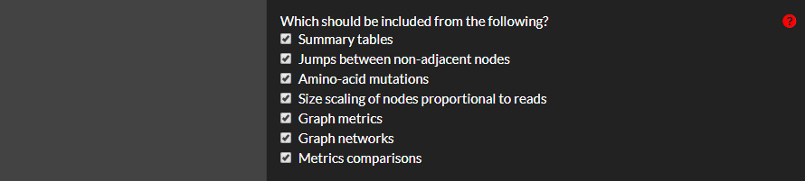

- **Summary tables**:  
  Tables with summary information [regarding nucleotide variants, sequences, mutational level,…] will be produced throughout the process.
- **Jumps between non-adjacent nodes**:  
  If selected, jumps are allowed and nt vars with common SHMs differing by two or more SHMs will be included.
- **Amino-acid mutations**:  
  The analysis will include the analysis of SHMs at the amino acid level. Replacement mutations will be shown in the graph and tables with the replacement mutations will be produced.
- **Size scaling of nodes proportional to reads**:  
  If selected, the size of the nodes of the graph networks will be proportional to the number of reads of the respective nucleotide variants.
- **Graph metrics**:  
  For each sample, different graph metrics will be calculated (description of the metrics below).
- **Graph networks**:  
  For each sample, a graph network representing the intraclonal diversification will be produced.
- **Metrics comparison**:  
  If the above **Graph metrics** option is selected, there is the option of performing metrics comparison between different groups of samples.

### Parameters: metrics

There are different metrics [or related calculations] that can be calculated for the description and determination of the intraclonal diversification level:

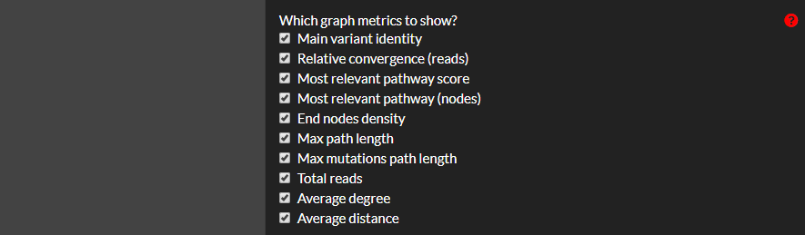

- **Main variant identity**:  
  Percentage (%) of identity of the main nucleotide variant with its respective germline.
- **Relative convergence (reads)**:  
  Graph metric “convergence score”. Ratio of the number of sequences of the most relevant pathways to the number of sequences of the main nucleotide variant. It shows the tendency for the BcR IG sequences to accumulate in the main nt var or to acquire additional convergent SHMs.
- **Most relevant pathway score**:  
  Each block of pathways that leads to a particular end node gets a score based on the ratio of the total number of sequences of the nodes forming that block of pathways to the total number of sequences of all the nodes of the network with more SHMs than the main nt var. The block with the highest score is the most relevant pathway, the one that will be used for the calculation of the relative convergence, the convergence score.
- **Most relevant pathway score (nodes)**:  
  Number of nodes of the most relevant pathway.
- **End nodes density**:  
  Graph metric.Ratio of the number of end nodes to the number of nucleotide variants with additional SHMs. It shows the randomness or specificity of the mutational path.
- **Max path length**:  
  Graph metric. Number of levels of additional SHMs. It shows the complexity of the mutational pathways.
- **Max mutations path length**:  
  Graph metric “maximal mutational length”. Maximum level of additional SHMs. It shows the complexity of the mutational pathway, allowing non-consecutive SHMs.
- **Total reads**:  
  Total number of reads of the sample.
- **Average degree**:  
  Graph metric. Average total number of connections of each nucleotide variant. It shows the complexity and connectivity of the mutational pathways.
- **Average distance**:  
  Graph metric. Average number of steps along the shortest pathways between each pair of nucleotide variants.

Then, it is possible to choose, among the graph metrics, which one(s) to use to perform comparisons between groups of samples.

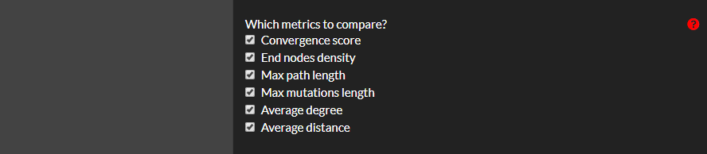

Once all the parameters have been selected, the button **Start** must be pressed. A bar will show how much of the analysis has been completed.

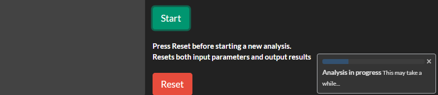

The button **Reset** can be used to start a new analysis, resetting the parameters and the output results.

## Visualize Results

When the analysis is finished, the **Visualize Results** tab will become active.

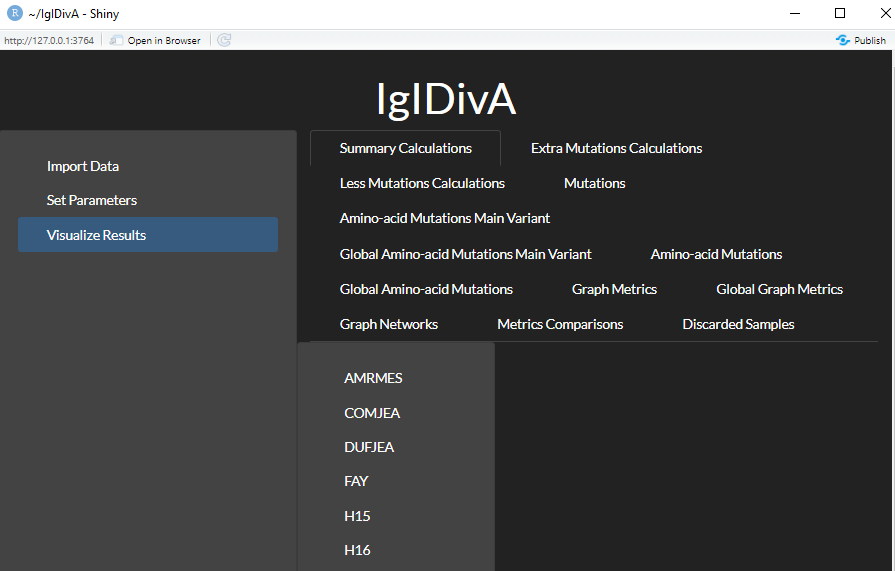

It shows all the different output results and it offers the possibility of selecting them and choosing which sample to visualize.

#### Summary Calculations

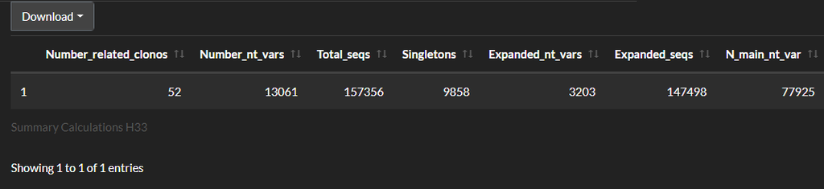

For each sample, it shows the number of related clonotypes [clonotypes with the same IGV gene and very similar CDR3] considered for the analysis, the number of nucleotide variants included, the total number of sequences, the number of singletons [nucleotide variants constituted by only one sequence], number of expanded nucleotide variants [nucleotide variants constituted by more than 1 sequence], number of sequences belonging to expanded nucleotide variants, and the number of reads of the main nucleotide variant.

#### Extra Mutations Calculations

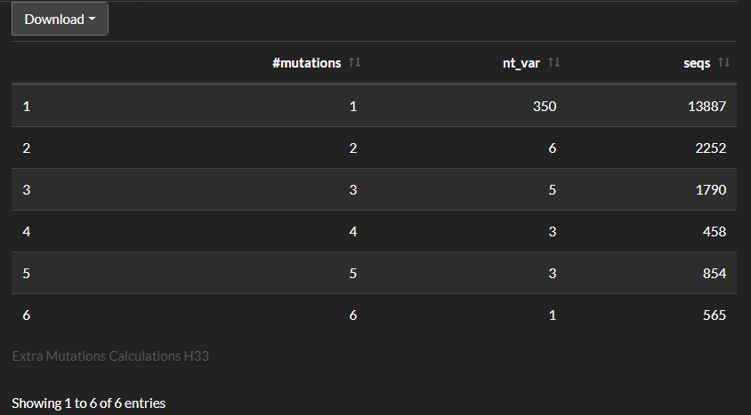

#### Less Mutations Calculations

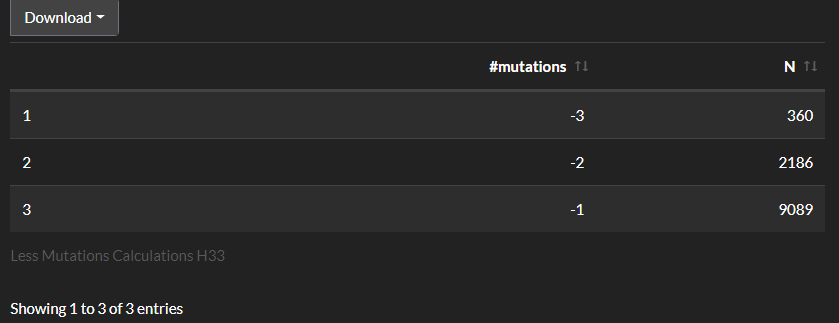

For each sample, it shows the number of sequences lacking SHMs of the main nt var, for each different number of SHMs.

#### Mutations

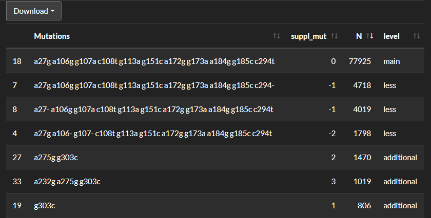

#### Amino-acid Mutations Main Variant

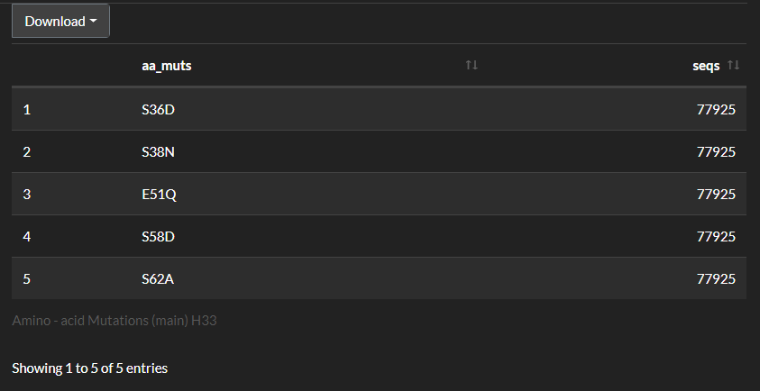

It provides information of the replacement SHMs in the main nt var of each sample, together with the number of sequences carring each mutation.

#### Gobal Amino-acid Mutations Main Variant

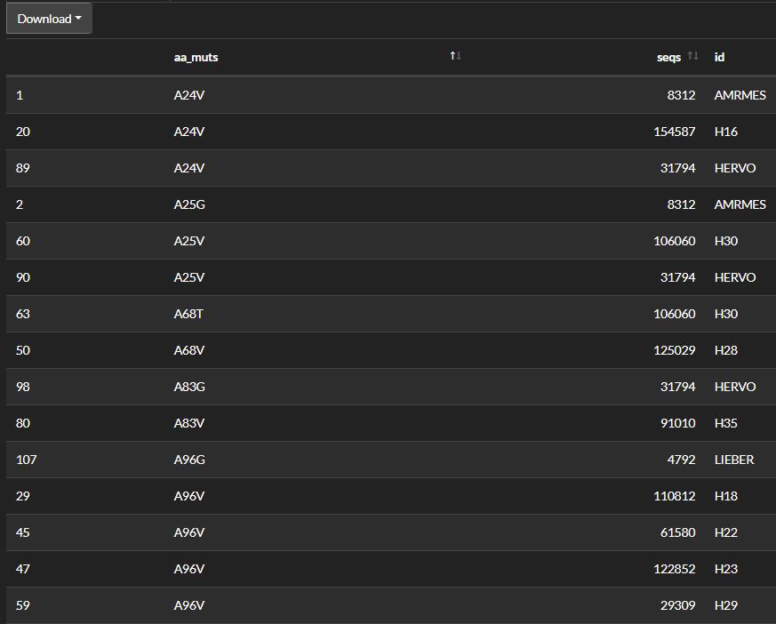

It contains all identified replacement SHMs in the main nt var of all the samples. It can be used to identify mutational patterns among samples.

#### Amino-acid Mutations

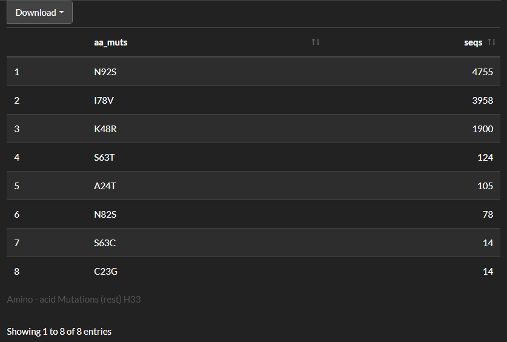

It contains all identified replacement SHMs in the nt vars with additional SHMs [excluding the ones of the main nt var].

#### Global Amino-acid Mutations

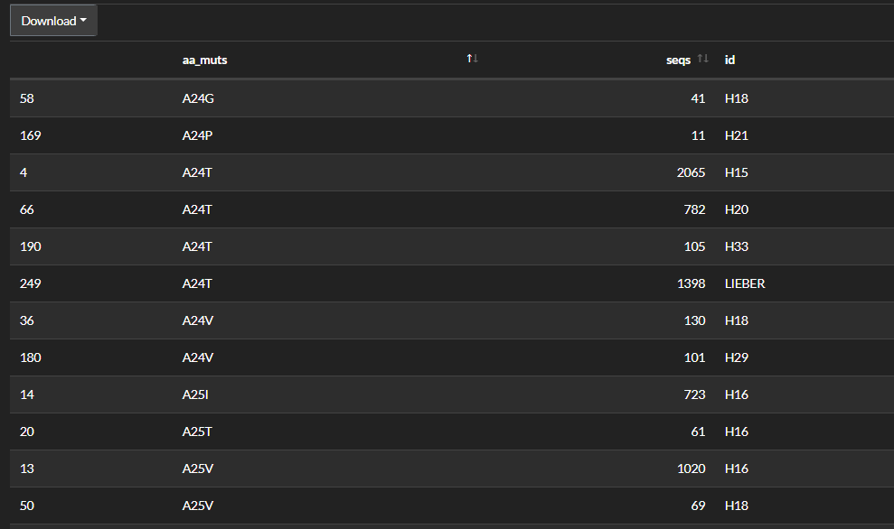

It contains all identified replacement SHMs in the nt vars with additional SHMs [excluding the ones of the main nt var] for all the samples. It can be used to identify mutational patterns among samples.

#### Graph Metrics

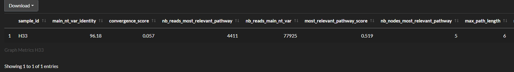

For each sample, it contains the germline identity %, the values of the graph metrics as well as information related to those metrics.

#### Global Graph Metrics

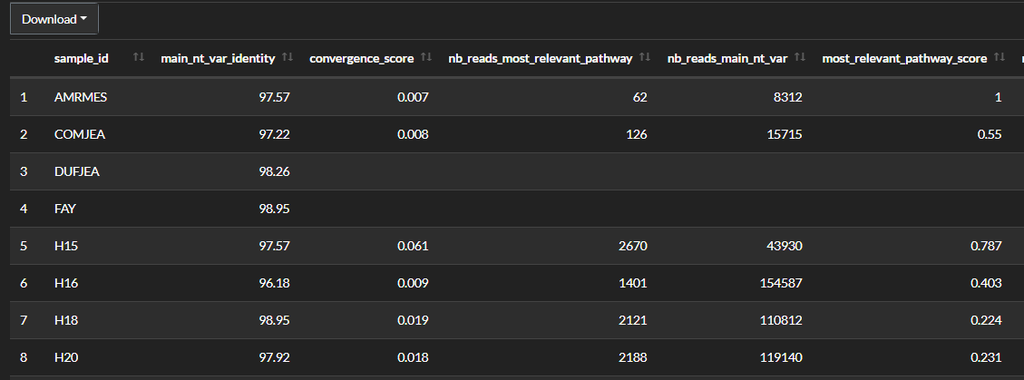

#### Graph Networks

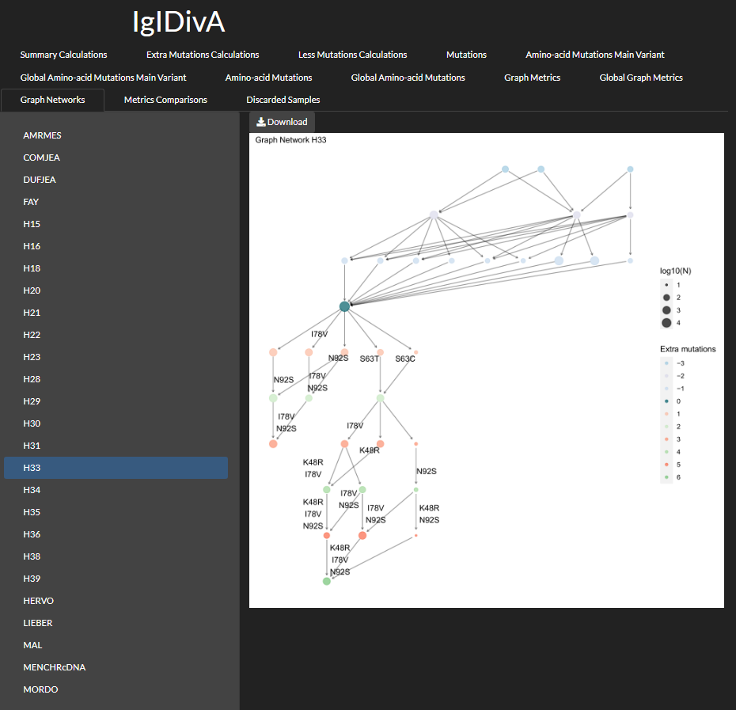

For each sample, it shows the graph network.

#### Metrics comparison

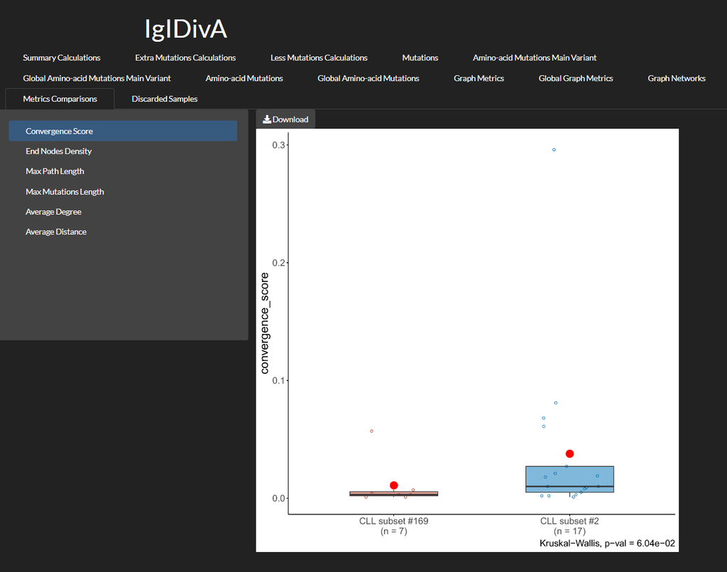

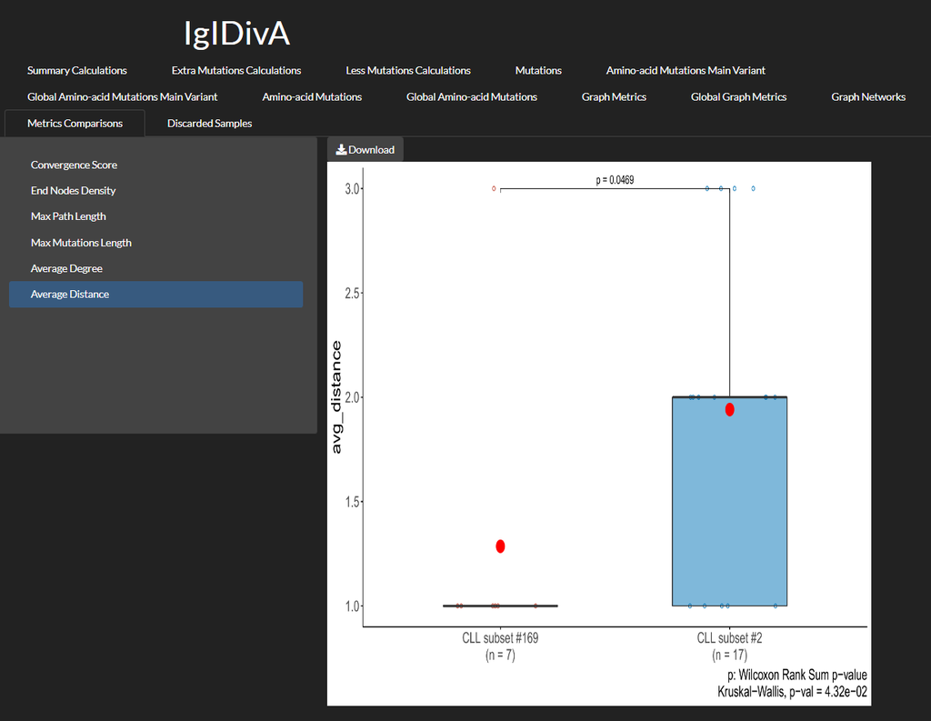

If samples are classified into groups, the tool performs pairwise comparisons for all groups. This is performed independently for each of the graph metrics.

#### Discarded Samples

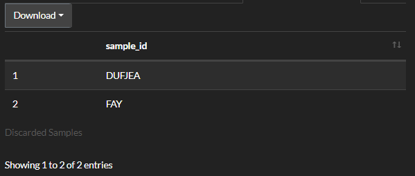

It provides the names of samples that have been discarded from the analysis [e.g. samples with no connections among nt vars].